# Natural Language Processing and Analysis

Tommy Brant

## Executive Summary

There are three files that contain English words to make up the corpora. Sources are from Twitter, News, and Blogs. These files will be analyzed to establish a corpora based on these samples. Word distribution will be analyzed to uncover insights. Additionally, we will exploring modeling to predict the next word in a phrase or sentence.

```r
library(tm)
library(quanteda)
library(stringi)
library(dplyr)
library(RWeka)
library(ggplot2)
library(wordcloud)
library(markovchain)
library(knitr)
library(readtext)
library(slam)
library(forcats)
```

## Loading the Data

The text data is from a corpus called HC Corpora (www.corpora.heliohost.org). See the readme file at http://www.corpora.heliohost.org/aboutcorpus.html for details on the corpora. The data are are comprised of text collected from publicly available sources by a web crawler. There are three sources - Twitter, News, and Blogs. We load the datasets below.

```r
file1 = "en_US.twitter.txt"
file2 = "en_US.news.txt"
file3 = "en_US.blogs.txt"

#Note, include encoding so it can interpret apastrophe's and single quotes appropriately
if (!exists("df_twitt")) df_twitt<-readLines("en_US.twitter.txt", encoding = "UTF-8")
if (!exists("df_news")) df_news<-readLines("en_US.news.txt", encoding = "UTF-8")
if (!exists("df_blogs")) df_blogs<-readLines("en_US.blogs.txt", encoding = "UTF-8")
if (!exists("df_total")) df_total<-c(df_twitt, df_news, df_blogs)
```

## Exploratory Analysis

Let’s look at contents, general file information and number of entries. Then we will probe further to find the number of words and sentences. Firstly, we preview the beginning and end of each source’s contents.

```r
#Contents by source

#Twitter first and last entries
head(df_twitt)
```

```
## [1] "How are you? Btw thanks for the RT. You gonna be in DC anytime soon? Love to see you. Been way, way too long."
## [2] "When you meet someone special... you'll know. Your heart will beat more rapidly and you'll smile for no reason."
## [3] "they've decided its more fun if I don't."
## [4] "So Tired D; Played Lazer Tag & Ran A LOT D; Ughh Going To Sleep Like In 5 Minutes ;)"
## [5] "Words from a complete stranger! Made my birthday even better :)"
## [6] "First Cubs game ever! Wrigley field is gorgeous. This is perfect. Go Cubs Go!"
```

```r
tail(df_twitt)
```

```
## [1] "and u didnt give it to him? lol"
## [2] "what's good. I see the success you got poppin in yo area."
## [3] "RT : Consumers are visual. They want data at their finger tips. Mobile is the only way to deliver this, 24/7."
## [4] "u welcome"
## [5] "It is #RHONJ time!!"
## [6] "The key to keeping your woman happy= attention, affection, treat her like a queen and sex her like a pornstar!"
```

```r
#News first and last entries
head(df_news,3)
```

```
## [1] "He wasn't home alone, apparently."
## [2] "The St. Louis plant had to close. It would die of old age. Workers had been making cars there since the onset of mass automotive production in the 1920s."
## [3] "WSU's plans quickly became a hot topic on local online sites. Though most people applauded plans for the new biomedical center, many deplored the potential loss of the building."
```

```r
tail(df_news,3)
```

```
## [1] "\"Given that there are no further tenders scheduled and the recent ECB rhetoric has been skewed toward this being the last, we believe the market will return to fundamentals and move away from this liquidity euphoria,\" analysts at Royal Bank of Scotland wrote in a research note."
## [2] "Ripley's strong performance is complemented by Asa Somers as Diana's patient, or perhaps depressed, husband, and by Emma Hunton as their neglected teenage daughter, Natalie. A talented musician and student, Natalie is the most sympathetic character in \"Next to Normal,\" a girl trying to rai…
## [3] "At the Spice Merchant, a 2-ounce bag of tea leaves capable of producing 1"
```

```r
#Blogs first and last enties
head(df_blogs,3)
```

```
## [1] "In the years thereafter, most of the Oil fields and platforms were named after pagan “gods”."
## [2] "We love you Mr. Brown."
## [3] "Chad has been awesome with the kids and holding down the fort while I work later than usual! The kids have been busy together playing Skylander on the XBox together, after Kyan cashed in his $$$ from his piggy bank. He wanted that game so bad and used his gift card from his birthday he has b…
```

```r
tail(df_blogs,3)
```

```
## [1] "Plus, I have also been allowing myself not to get ‘stressed’ over things that have not been done! If the ironing is not done right now, it’s not the end of the world! If that phone call is made tomorrow rather than today, then that’s OK too! Living in the moment and allowing myself the time …
## [2] "(5) What's the barrier to entry and why is the business sustainable?"
## [3] "In response to an over-whelming number of comments we sat down and created a list of do (s) and don’t (s) – these recommendations are easy to follow and except for - adding some herbs to your rinse . So let’s get begin…"
```

Preview the file size and volume of entries within.

```r
# File Size and length entries, in Bytes

filesize_Bytes<-c(file.info(file1)$size, file.info(file2)$size, file.info(file3)$size)

# Number of entries or documents
N_entries<-c(length(df_twitt), length(df_news), length(df_blogs))

source_info<-rbind(filesize_Bytes, N_entries)
colnames(source_info)<-c("Twitter", "News", "Blogs")
kable(t(source_info))
```

|  | filesize_Bytes | N_entries |
| --- | --- | --- |
| Twitter | 167105338 | 2360148 |
| News | 205811889 | 77259 |
| Blogs | 210160014 | 899288 |

Next, let’s organize the data by sentence and word count. Thanks to the stringi package for making this process simple.

```r
#requires stringi package

#DETERMINE SENTENCE BOUNDARIES. RETURNS # OF TEXT BOUNDARIES(char, word, line, OR sentence)

#number of sentence boundaries per entry/document
sentBound_blogs<-stri_count_boundaries(df_blogs,type="sentence")
sentBound_news<-stri_count_boundaries(df_news,type="sentence")
sentBound_twitt<-stri_count_boundaries(df_twitt,type="sentence")

#number of words per entry/document
numWords_blogs<-stri_count_words(df_blogs)
numWords_news<-stri_count_words(df_news)
numWords_twitt<-stri_count_words(df_twitt)

# num Words per source
wordsTot<-c(sum(numWords_twitt), sum(numWords_news), sum(numWords_blogs))

# num sentences per source
sentTot<-c(sum(sentBound_twitt), sum(sentBound_news), sum(sentBound_blogs))

# num words per sentence on avg
words_per_sent<-wordsTot/sentTot

source_info<-rbind(source_info, wordsTot, sentTot, words_per_sent)
source_info
```

```
##                     Twitter         News        Blogs
## filesize_Bytes 1.671053e+08 2.058119e+08 2.101600e+08
## N_entries      2.360148e+06 7.725900e+04 8.992880e+05
## wordsTot       3.009337e+07 2.674536e+06 3.754624e+07
## sentTot        3.770155e+06 1.554360e+05 2.375718e+06
## words_per_sent 7.981999e+00 1.720667e+01 1.580416e+01
```

```r
#make easier to read
source_info[1:4,]<-format(source_info[1:4,], scientific = FALSE)
source_info[5,]<-format(round(as.numeric(source_info[5,]), 2), scientific = FALSE)

#--IS THIS NEEDED?
kable(t(source_info[1:2,]))
```

|  | filesize_Bytes | N_entries |
| --- | --- | --- |
| Twitter | 167105338 | 2360148 |
| News | 205811889 | 77259 |
| Blogs | 210160014 | 899288 |

## Sampling the Data

How we define our corpus will have an impact on the results. For example, we have the option of combining all the data into a single data set before defining the corpus. For a predictive text model, this would introduce bias towards the source(s) with more words per sentence and more sentences. Alternatively, a more precise model could be created if we define a corpus per data set, and use a predictive model with the three corpora.

Given the size of the data sets, we will sample of each data set will be taken, then combine the samples to define the corpus.

We will track the source of the text in our explorations.

```r
library(dplyr)

#----tracking sample source is not necessary at this point since we are done with explo word analysis
set.seed(8465) #for sampling
#blogs
n<-0.05 #sampling volume # 5%



#blog
if (!exists("blogs.sample")) blogs.sample<-df_blogs[sample(length(df_blogs),length(df_blogs)*n)] #random sampling
if (!exists("blogs.sample.df")) blogs.sample.df<-data.frame(text=blogs.sample,source=rep("blogs",length(blogs.sample))) #~15s


#news
if (!exists("news.sample")) news.sample<-df_news[sample(length(df_news),length(df_news)*n)]
if (!exists("news.sample.df")) news.sample.df<-data.frame(text=news.sample,source=rep("news",length(news.sample)))

#twitter

if (!exists("twitt.sample")) twitt.sample<-df_twitt[sample(length(df_twitt),length(df_twitt)*n)]
if (!exists("twitt.sample.df")) twitt.sample.df<-data.frame(text=twitt.sample,source=rep("twitt",length(twitt.sample)))


#combine
if (!exists("textTotSamp")) textTotSamp<-rbind(blogs.sample.df,news.sample.df,twitt.sample.df)
textTotSamp$text<-as.character(textTotSamp$text)
```

Visualize corpus structure

```r
#-----Visualize corpus structure by document
summary(corpus(textTotSamp$text), 5)
```

```
## Corpus consisting of 166833 documents, showing 5 documents:
##
##   Text Types Tokens Sentences
##  text1    85    139         8
##  text2    49     60         2
##  text3    18     21         1
##  text4    88    124         5
##  text5    57     79         4
##
## Source: D:/Analyst/COURSERA DATA SCIENCE test/COURSECAPSTONE/* on x86-64 by Tombomb
## Created: Sat Jan 25 15:41:40 2020
## Notes:
```

Each entry from our text source is treated as a document. The documents will be split into sentences prior to vector corpus construction. This will be helpful when we identify unigrams, bi grams, and tri grams. Worth noting that we could split the documents into words, but the N-gram analysis would not factor in complete sentences, and the memory used would be much greater.

```r
library(quanteda)
library(tm)

#-----break up documents into sentences
if (!exists("text.by.sent.1")) text.by.sent.1<-unlist(tokens(textTotSamp$text,what="sentence"))

#sentences
if (!exists("text.corpus.1")) text.corpus.1<-VCorpus(VectorSource(text.by.sent.1))
```

## Memory Cleanup (Under Construction)

Natural language proessing requires an abundance of processing power for a moderate sample.

```r
#--------CLEAN MEMORY
#rm(list=c("text.corpus1","textClean", "textCorpus","text.corpus","clean_split", "clean.Corpus","bar_bi", "bar_bi_flip","bar_tri", "bar_tri_flip", "df1.1", "df1","df1.2", "df1.3", "df2.1word", "df3.1", "sample_blogs", "sample_news","sample_twitt"))

#rm(list=c("text.by.sent", "text.by.sent.2", "text.by.sent.test", "text.by.sent.test1.1", "corpusQ", "corpusQ_sumry", "freq_quad")
```

## Cleaning the Corpus

Next, we work to clean the corpus for token analysis.

There are some packages that are commonly used, such as Quanteda and tm. Will will use the tm_map function from tm package.

Tokenization will be performed on the corpus prior to ultimately creating the term document matrix. This includes removing punctuations, URLs, leading/lagging spaces, emojis, whitespace, and profanities. We could also remove stopwords, but since we want to build a model to predict text, we will leverage the stop words.

The list of profane words can be found at https://raw.githubusercontent.com/LDNOOBW/List-of-Dirty-Naughty-Obscene-and-Otherwise-Bad-Words/master/en

```r
#---TM_MAP()


#-------------- DEFINE PROFNAITIES
if (!exists("prof")) prof<-readLines("Data/PROFANITIES/prof.txt")
if (!exists("prof_clean")) prof_clean<-tolower(prof)

#-------functions for tm_map
remove_Num_Punct<- function(x){
    gsub("[^[:alpha:][:space:]]*","",x)
}

# 1.1 -Remove spaces
remove_Spaces_LeadTail<-function(x){
    gsub("^\\s+|\\s+$", "", x)
}

# 2 -Remove URL prefixes
remove_URL <- function(x){
    gsub("http[^[:space:]]*","",x)
}


#----------replace non-vonc bytes w/ hexcode strings
if (!exists("vector.corpus.1")) {
  vector.corpus.1<-tm_map(text.corpus.1, content_transformer(function(x) iconv(enc2utf8(x), sub = "byte")))
  #alternate------- for replacing graphics with spaces - usableText=str_replace_all(tweets$text,"[^[:graph:]]", " ")
  vector.corpus.1<- tm_map(vector.corpus.1,content_transformer(remove_URL))
  vector.corpus.1<- tm_map(vector.corpus.1,removeNumbers)
  vector.corpus.1<- tm_map(vector.corpus.1,removePunctuation)
  vector.corpus.1<- tm_map(vector.corpus.1,stripWhitespace)
  vector.corpus.1<- tm_map(vector.corpus.1,content_transformer(tolower))
  vector.corpus.1<- tm_map(vector.corpus.1,removeWords,prof_clean)  #this takes the longest ~30s @ 1% sample
}
```

Now that we have vector corpus in place, let’s start to visualize the word distribution.

## Wordcloud

Basic wordcloud to qualitatively visualize frequency of words

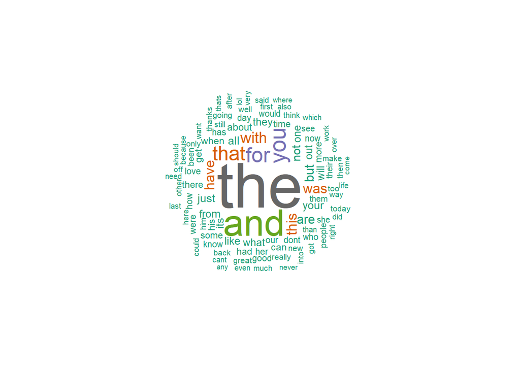

```r
#library(wordcloud)

if (!exists("wc")) wc<-wordcloud(vector.corpus.1, scale=c(5,0.5), max.words=100, random.order=FALSE, rot.per=0.4, use.r.layout=FALSE, colors=brewer.pal(8, "Dark2"))
```

```r
wc
```

As expected, the most common words are stop words from the English dictionary.

Given we desire to make a model for predictive text, we will not remove stop words. Let’s look at word frequency next. The data will be organized into a Term Document Matrix to look at word frequency.

Term Document Matrix will be created for N-gram analysis.

```r
#library(RWeka)
#library(tm)
#install.packages("slam")
#library(slam)  #for row_sums


#---UNIGRAM TDM

if (!exists("tdm_uni")) tdm_uni<-TermDocumentMatrix(vector.corpus.1, control = list(wordLengths=c(1,Inf), tokenize =function (x) NGramTokenizer(x, Weka_control(min=1, max = 1))))


#------------------BI GRAM TDM
#takes ~35s
if (!exists("tdm_bi")) tdm_bi<-TermDocumentMatrix(vector.corpus.1, control = list(wordLengths=c(1,Inf), tokenize =function (x) NGramTokenizer(x, Weka_control(min=2, max = 2))))

#nrow(tdm_bi)


#------------TRI GRAM TDM

if (!exists("tdm_tri")) tdm_tri<-TermDocumentMatrix(vector.corpus.1, control = list(wordLengths=c(1,Inf), tokenize =function (x) NGramTokenizer(x, Weka_control(min=3, max = 3))))

#nrow(tdm_tri)

#---------------QUAD GRAM TDM
#------(SIZE ANOMALY?)

if (!exists("tdm_quad")) tdm_quad<-TermDocumentMatrix(vector.corpus.1, control = list(wordLengths=c(1,Inf), tokenize =function (x) NGramTokenizer(x, Weka_control(min=4, max = 4))))

#nrow(tdm_quad)
```

Now that the TDMs are constructed, we leverage helper functions to show frequency by N-gram.

```r
#library(RWeka)
#library(tm)
#install.packages("slam")
#library(slam)  #for row_sums
#------OPTION 2, OKAY MEMORY ALLOCATION
#-------------unigram freq opt 2, do sums outside of as.matrix call, then cbind


#dim(tdm_uni) #44568 x 62652 (why so big?) dumb sparse matrix

unigram_frequency2 <- function(tdm_){

    #---row_sums from slam pkg.
    #---- I think na.rm=TRUE is necess due to tokens coercion
    token_sums <- (row_sums(tdm_, na.rm=TRUE)) # total freq #getting error about sorting
    token.sums.df<- data.frame(cbind(names(token_sums), token_sums),
                           stringsAsFactors = FALSE)
    names(token.sums.df)<-c("token","freq")
    token.sums.df$freq <- as.numeric(token.sums.df$freq)
    #sort by frequency
    token.sums.df<-token.sums.df[order(token.sums.df$freq, decreasing=TRUE),]
    token.sums.df$token <- as.factor(token.sums.df$token)
    #sort levels so plot looks good
    token.sums.df$token<-factor(token.sums.df$token, levels=token.sums.df$token[order(token.sums.df$freq)])


    return(token.sums.df)
}

if (!exists("freq_uni1.2")) freq_uni1.2<-unigram_frequency2(tdm_uni)
if (!exists("freq_bi1.2")) freq_bi1.2<-unigram_frequency2(tdm_bi)
if (!exists("freq_tri1.2")) freq_tri1.2<-unigram_frequency2(tdm_tri)
if (!exists("freq_quad1.2")) freq_quad1.2<-unigram_frequency2(tdm_quad)
```

# Token Frequency

Let’s view the tokens based on frequency.

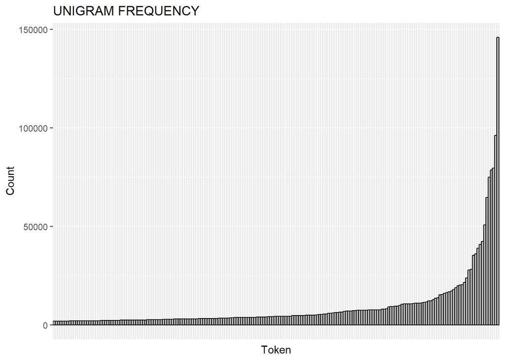

```r
#frequency plot in bar plot format -- still mind this is news sample only
#has no fill
#library(ggplot2)
#library(dplyr)
#library(forcats)

#head(freq_uni)
#------------------------GENERAL TOKENS PLOT
#----- HOW IS THIS DIFF THAN UNIGRAM? - COLOR AND VIEWING
#----SHOWING THIS IS SHOWING EXPLORATORY ANALYSIS(NOT TERRIBLE)

#

if (!exists("gen_plot")) gen_plot<-ggplot(filter(freq_uni1.2, freq>1)[1:200,],aes(x=token,y=freq))+  #filter freq >1
        geom_bar(stat="identity", width=1, fill="green3",color="black")+ # fill="steelblue2")+
        geom_bar(stat="identity", width=1, fill="gray72",color="black")+ # fill="steelblue2")+
        ylab("Count")+
        xlab("Token")+
        ggtitle("UNIGRAM FREQUENCY") +
        theme(axis.text.x=element_blank(),
              axis.ticks.x=element_blank())

gen_plot
```

# N-gram Visualizations

Unigram distribution

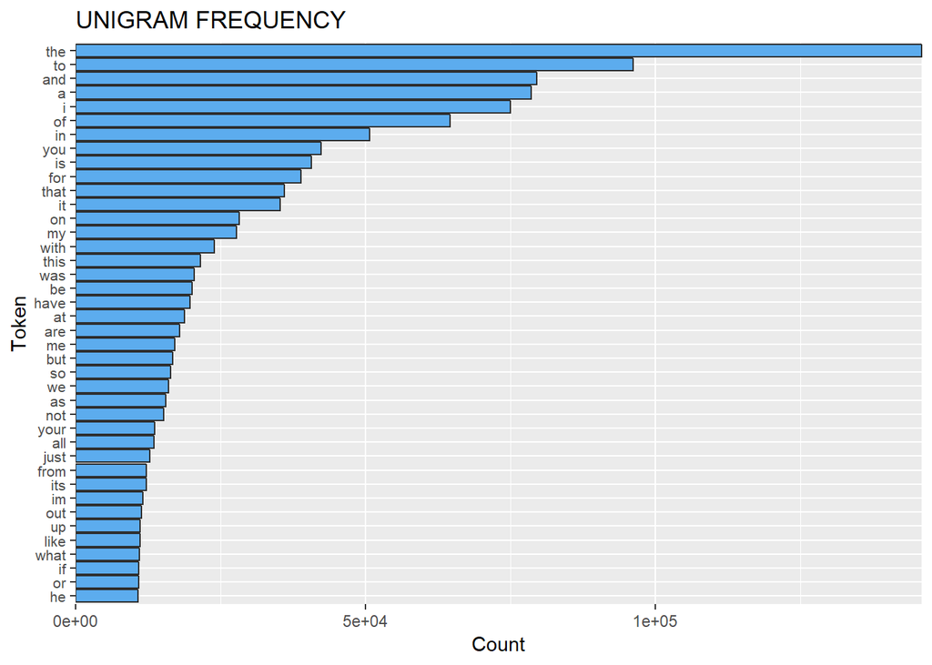

```r
#-----------------------unigram plot
library(ggplot2)
library(dplyr)
library(forcats)


if (!exists("bar_plot1")) bar_plot1<-ggplot(filter(freq_uni1.2, freq>1)[1:40,],aes(x=token,y=freq))+
        geom_bar(stat="identity", fill="steelblue2", color="grey18") +#
        coord_flip()+
        ylab("Count")+xlab("Token")+
        ggtitle("UNIGRAM FREQUENCY") +
        theme(axis.text.y = element_text(size=8)) +
        scale_y_continuous(expand=c(0,0)) #removes space
bar_plot1
```

Bi-Gram distribution

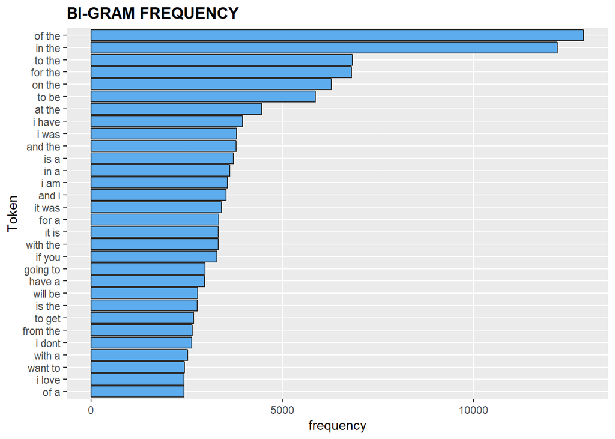

```r
library(ggplot2)
library(dplyr)
library(forcats)


#-------bi gram plot
if (!exists("bar_plot2")) bar_plot2<-ggplot(filter(freq_bi1.2, freq>1)[1:30,],aes(x=token,y=freq), fill="steelblue")+
#bar_plot1<-ggplot(freq_uni,aes(x=token,y=freq,fill=sw))+
        geom_bar(stat="identity", fill="steelblue2", color="grey18") +#
        coord_flip()+
        ylab("frequency")+xlab("Token")+
        ggtitle("BI-GRAM FREQUENCY") +
        theme(plot.title = element_text(lineheight=.7, face="bold"))+
        theme(legend.title=element_blank())


bar_plot2
```

Tri-Gram distribution

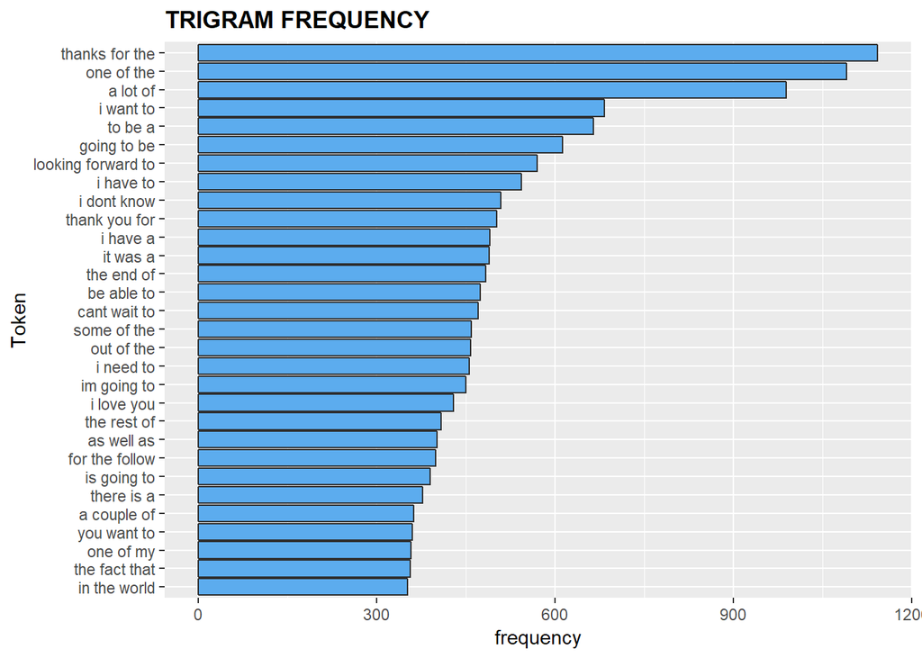

```r
#------tri gram plot
if (!exists("bar_plot3")) bar_plot3<-ggplot(filter(freq_tri1.2, freq>1)[1:30,],aes(x=token,y=freq))+
#bar_plot1<-ggplot(freq_uni,aes(x=token,y=freq,fill=sw))+
        geom_bar(stat="identity", fill="steelblue2", color="grey18") +#
        coord_flip()+
        ylab("frequency")+xlab("Token")+
        ggtitle("TRIGRAM FREQUENCY") +
        theme(plot.title = element_text(lineheight=.7, face="bold"))+
        theme(legend.title=element_blank())


bar_plot3
```

# Observations and Next Steps

Now that we have some idea as to word distribution. We can use N-grams to predict the next word. A number of machine learning algorithms could be applied for this(including random forest), but we anticipate Markov Chain modeling may prove to be an efficient way to predict text.

We will next explore constructing the Markov Chain model, and validating it’s use. After a model has been created, we will explore way upon which it can be packaged